# IODS course project

Daniel Kawecki

# About the project

## Introduction to Open Data Science.

### My expectations for IODS

I am working on my research plan and I need to do some preliminary data exploration in the data from the Finnish National Election Studies. This course conveniently came up in WebOodi and seems to cover the tools I will need to start working with the data. I have had some previous experience with data science from a course that used Python, but I didn’t complete the course because it moved so fast from the basics to things like machine learning that I couldn’t keep up. From what I can see so far, this course seems to have a more realistic scope for an introduction and R will probably be very useful for me.

### Repository link

Link to my repository: [https://github.com/dakaw/IODS-project]

# Regression and model validation

This week we have learned how to examine the structure and dimensions of a dataset, how to plot desciptive statistics and correlations between the variables and how to fit linear regression models to the data. Furthermore, we have examined how to run diagnostic analysis on the fitted model in order to examine the underlying assumptions of for examoke normally distributed residuals and constant variance in the residuals.

## Data analysis for Data Studio Exercise 2

```r
library(dplyr)
library(GGally)
```

```r
library(ggplot2)
```

### Data and structure

First, we read the data set and look at the data structure. I will use the file I generated in the data wrangling exercise.

```r
my_data <- read.table("data/analysis_lrn2014.csv", sep = ";")
str(my_data)
```

```
## 'data.frame':    166 obs. of  7 variables:
##  $ gender  : Factor w/ 2 levels "F","M": 1 2 1 2 2 1 2 1 2 1 ...
##  $ age     : int  53 55 49 53 49 38 50 37 37 42 ...
##  $ attitude: int  37 31 25 35 37 38 35 29 38 21 ...
##  $ deep    : num  3.58 2.92 3.5 3.5 3.67 ...
##  $ stra    : num  3.38 2.75 3.62 3.12 3.62 ...
##  $ surf    : num  2.58 3.17 2.25 2.25 2.83 ...
##  $ points  : int  25 12 24 10 22 21 21 31 24 26 ...
```

The data set consists of 166 observations of students. We measure 7 variables about each student, starting with age and gender. The variable ‘attitude’ measures the student’s global attitude towards statistics. Then follows three measures of the student’s abilities for deep learning, strategic learning and surface learning. These three measures are the mean value of several other questions in the original data material. Finally, the ‘points’ variable measures the students exam points.

### Graphical overview and initial interpretation

I will use the ggpairs function to generate matrix plot of the distributions and correlations between all variables.

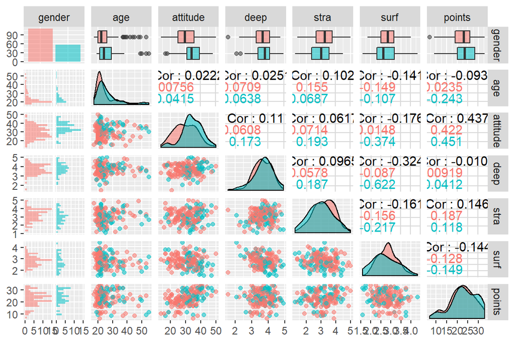

```r
ggpairs(my_data, mapping = aes(col = my_data$gender, alpha=0.3),lower = list(combo = wrap("facethist", bins = 20)))
```

We can make the following general observations of the data - There are twice as many women in the observations as men - Most of the students are under 30 years old - Men have a slightlu more positive attitude towards statistics while women score slightly better in strategic and surface learning. - The variables with the greates correlations to points on the test are attitude (0.437), strategic learning (0.146) and surface learning (-0,144) - There are weak positive correlations between deep learning, strategic learning and attitude. At the same time, all correlations are negative with surface learning. This indicates that students with a positive attitude also tend to have more developed strategic and deep learning abilities, and out of those especially a positive attitude and strategic learning predict better scores on the test while deep learning does not affect test results more than marginally. Students with less postitive attitudes tend to be better at surface learning and score worse in the test.

From these observations we can fit a regression model.

### Regression model

Which variables explain better scores on the test? From the previous analysis, we can see that attitude and strategich learning have the strongest positive correlations with points, while surface learning has the third strongest but negative correlation. We use these three variables as explanatory variables and points as the target variable to fit a regression model:

```r
model <- lm(points ~ attitude + stra + surf, data = my_data)
summary(model)
```

```
##
## Call:
## lm(formula = points ~ attitude + stra + surf, data = my_data)
##
## Residuals:
##      Min       1Q   Median       3Q      Max
## -17.1550  -3.4346   0.5156   3.6401  10.8952
##
## Coefficients:
##             Estimate Std. Error t value Pr(>|t|)
## (Intercept) 11.01711    3.68375   2.991  0.00322 **
## attitude     0.33952    0.05741   5.913 1.93e-08 ***
## stra         0.85313    0.54159   1.575  0.11716
## surf        -0.58607    0.80138  -0.731  0.46563
## ---
## Signif. codes:  0 '***' 0.001 '**' 0.01 '*' 0.05 '.' 0.1 ' ' 1
##
## Residual standard error: 5.296 on 162 degrees of freedom
## Multiple R-squared:  0.2074, Adjusted R-squared:  0.1927
## F-statistic: 14.13 on 3 and 162 DF,  p-value: 3.156e-08
```

From the above model summary, we can see that only the intercept and attitude where statistically significant. The likelihood that the correlation between the variables is due to chance is less than 0,1% for attitude and less than 1% for attitude. However, effect of strategic and surface learning is not sufficiently statistically significant. I will therefore remove them from the model and fit a new model with only attitude as an explanatory variable.

```r
model <- lm(points ~ attitude, data = my_data)
summary(model)
```

```
##
## Call:
## lm(formula = points ~ attitude, data = my_data)
##
## Residuals:
##      Min       1Q   Median       3Q      Max
## -16.9763  -3.2119   0.4339   4.1534  10.6645
##
## Coefficients:
##             Estimate Std. Error t value Pr(>|t|)
## (Intercept) 11.63715    1.83035   6.358 1.95e-09 ***
## attitude     0.35255    0.05674   6.214 4.12e-09 ***
## ---
## Signif. codes:  0 '***' 0.001 '**' 0.01 '*' 0.05 '.' 0.1 ' ' 1
##
## Residual standard error: 5.32 on 164 degrees of freedom
## Multiple R-squared:  0.1906, Adjusted R-squared:  0.1856
## F-statistic: 38.61 on 1 and 164 DF,  p-value: 4.119e-09
```

From the above model, we see that each point in attitude increases the test result with 0.35 points. The R-squared value shows 0.19, meaning that 19% of the variation in test scores can be explained by the students attitude towards statistics.